# Ecological Forecasting Lab 3 - AR(1) Model

Seth Romero

2023-02-08

### Initial setup

Pulling in NDVI data and excluding final 10 observations for later model testing. Taking some precautionary measures to ensure data is complete, consistent, and does not otherwise have abnormalities that would throw off model fit. Could nest variable calculations in the model itself, but there is some advantage to storing explicitly with the model’s input dataframe to make downstream utilization or variable exploration easier.

```r
library(tidyr)
library(dplyr)
library(lubridate)
library(stringr)
library(ggplot2)

setwd("~/Documents/GitHub/CourseResources/EcologicalForecasting/assignments/")

# just being explicit about setting/ordering dates,
# setting an ordered index,
# and calculating time intervals between observations
full_ts <- read.csv("../data/portal_timeseries.csv") %>%
  mutate(date = mdy(date)) %>%
  arrange(date) %>%
  mutate(i = seq(1, length(.$NDVI)),
         date_intrvl = time_length((date - lag(date, n = 1)), unit = "days"))

# calculating t-1 values,
# removing final 10 dates
obs_ts <- full_ts %>%
  mutate(prev_ndvi = lag(NDVI, n = 1),
         prev_rain = lag(rain, n = 1)) %>%
  filter(i <= (max(i) - 10))

# Checking NA structure,
# totals by column...
colSums(is.na(obs_ts))
```

```
##           X        NDVI        rain     rodents        date           i date_intrvl   prev_ndvi   prev_rain
##           0           0           0           0           0           0           1           1           1
```

```r
# NAs should be at i=1 only, checking...
obs_ts[which(is.na(obs_ts$prev_ndvi) | is.na(obs_ts$prev_rain) | is.na(obs_ts$date_intrvl)), ]
```

```
##   X     NDVI rain  rodents       date i date_intrvl prev_ndvi prev_rain
## 1 1 0.181375 39.3 445.8643 1992-03-15 1          NA        NA        NA
```

```r
# Checking for time interval consistency,
# interval calculated in days...
summary(obs_ts$date_intrvl)
```

```
##    Min. 1st Qu.  Median    Mean 3rd Qu.    Max.    NA's
##   28.00   30.00   31.00   30.44   31.00   31.00       1
```

*1. Fit a AR(1) model to the NDVI observed data using the lm function. You will need to use indexing to match up NDVI<sub>t</sub> with NDVI<sub>t-1</sub>.*

```r
# first model based on NDVI at t-1 only
ndviM1 <- glm(NDVI ~ prev_ndvi,
              data = obs_ts)

summary(ndviM1)
```

```
##
## Call:
## glm(formula = NDVI ~ prev_ndvi, data = obs_ts)
##
## Deviance Residuals:
##       Min         1Q     Median         3Q        Max
## -0.082566  -0.020325  -0.011026   0.004754   0.225227
##
## Coefficients:
##             Estimate Std. Error t value Pr(>|t|)
## (Intercept) 0.062915   0.008817   7.136 9.58e-12 ***
## prev_ndvi   0.645485   0.047426  13.610  < 2e-16 ***
## ---
## Signif. codes:  0 '***' 0.001 '**' 0.01 '*' 0.05 '.' 0.1 ' ' 1
##
## (Dispersion parameter for gaussian family taken to be 0.001724008)
##
##     Null deviance: 0.76760  on 261  degrees of freedom
## Residual deviance: 0.44824  on 260  degrees of freedom
##   (1 observation deleted due to missingness)
## AIC: -919.62
##
## Number of Fisher Scoring iterations: 2
```

*2.Create a function to forecast the NDVI, and forecast the 10 months of the NDVI data that we witheld, treating the last observed value as your initial condition. Plot the forecast for the next ten months along points for the withheld data. This function will is very similar to logistic growth function we built in lab 1. You can extract the model parameters using model$coefficients.*

```r
betasM1 <- ndviM1$coefficients
betasM1
```

```
## (Intercept)   prev_ndvi
##  0.06291518  0.64548481
```

```r
# pulling final 11 dates and observed NDVI from initial data
fullLen <- length(full_ts$i)
obsFinal <- max(obs_ts$i)
dateSubset <- full_ts$date[(fullLen - 10) : fullLen] # subtracting 10 leads to inclusion of 11 values
obsNDVI <- full_ts$NDVI[(fullLen - 10) : fullLen]

# initial NDVI value from which forecast is generated
initNDVI <- obs_ts$NDVI[obsFinal]

# function to calculate predicted values
# ...could alter to take additional optional beta arguments for more flexible AR(p) handling
# but not doing that for now...
calc.pred1 <- function(init, x1, b0, b1){
  vec = numeric(length(x1))
  vec[1] = init
  for (t in 2:length(x1)){
    vec[t] = b0 + (b1 * vec[t-1])
  }
  return(vec)
}

# generate dataframe with forecasted and observed NDVI values
pred_ts1 <- data.frame(date = dateSubset,
                       ndvi_observed = obsNDVI,
                       ndvi_predicted = NA) %>%
  mutate(ndvi_predicted = calc.pred1(init = initNDVI,
                                     x1 = ndvi_predicted,
                                     b0 = betasM1[1],
                                     b1 = betasM1[2])) %>%
  pivot_longer(cols = c("ndvi_observed", "ndvi_predicted"), names_to = "value_type", values_to = "NDVI") %>%
  mutate(value_type = str_sub(value_type, 6))

head(pred_ts1)
```

```
## # A tibble: 6 × 3
##   date       value_type  NDVI
##   <date>     <chr>      <dbl>
## 1 2014-01-15 observed   0.144
## 2 2014-01-15 predicted  0.144
## 3 2014-02-15 observed   0.140
## 4 2014-02-15 predicted  0.156
## 5 2014-03-15 observed   0.145
## 6 2014-03-15 predicted  0.164
```

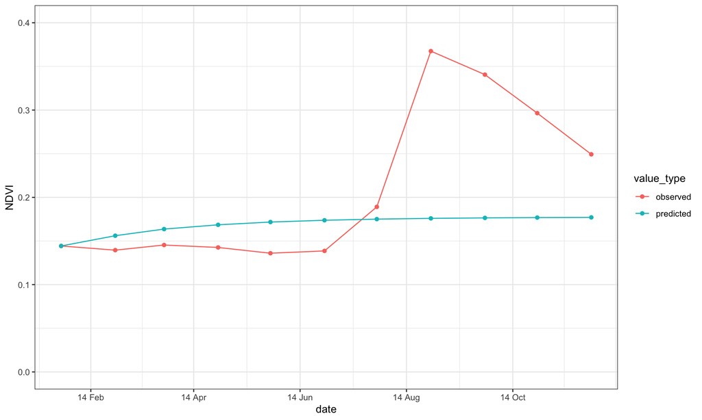

```r
ggplot(data = pred_ts1, aes(x = date, y = NDVI, color = value_type)) +
  geom_point() +
  geom_line() +
  scale_y_continuous(limits = c(0, 0.4)) +
  scale_x_date(breaks = "2 months",
               date_labels = "%y %b") +
  theme_bw()
```

*3. Repeat steps 1 & 2 using rain<sub>t-1</sub> along with NDVI<sub>t-1</sub> to explain NDVI<sub>t</sub>.*

```r
# second model based on NDVI at t-1 and rain at t-1
ndviM2 <- glm(NDVI ~ prev_ndvi + prev_rain,
              data = obs_ts)

summary(ndviM2)
```

```
##
## Call:
## glm(formula = NDVI ~ prev_ndvi + prev_rain, data = obs_ts)
##
## Deviance Residuals:
##       Min         1Q     Median         3Q        Max
## -0.079845  -0.017562  -0.006102   0.006995   0.193255
##
## Coefficients:
##              Estimate Std. Error t value Pr(>|t|)
## (Intercept) 5.905e-02  7.662e-03   7.707 2.76e-13 ***
## prev_ndvi   5.744e-01  4.186e-02  13.721  < 2e-16 ***
## prev_rain   7.852e-04  8.454e-05   9.289  < 2e-16 ***
## ---
## Signif. codes:  0 '***' 0.001 '**' 0.01 '*' 0.05 '.' 0.1 ' ' 1
##
## (Dispersion parameter for gaussian family taken to be 0.001298201)
##
##     Null deviance: 0.76760  on 261  degrees of freedom
## Residual deviance: 0.33623  on 259  degrees of freedom
##   (1 observation deleted due to missingness)
## AIC: -992.95
##
## Number of Fisher Scoring iterations: 2
```

```r
betasM2 <- ndviM2$coefficients
betasM2
```

```
##  (Intercept)    prev_ndvi    prev_rain
## 0.0590507745 0.5743707732 0.0007852313
```

```r
obsRain <- full_ts$rain[(fullLen - 10) : fullLen]

calc.pred2 <- function(init, x1, x2, b0, b1, b2){
  vec = numeric(length(x1))
  vec[1] = init
  for (t in 2:length(x1)){
    vec[t] = b0 + (b1 * vec[t-1]) + (b2 * x2[t-1])
  }
  return(vec)
}

pred_ts2 <- data.frame(date = dateSubset,
                       ndvi_observed = obsNDVI,
                       rain = obsRain,
                       ndvi_predicted = NA) %>%
  mutate(ndvi_predicted = calc.pred2(init = initNDVI,
                                     x1 = ndvi_predicted,
                                     x2 = rain,
                                     b0 = betasM2[1],
                                     b1 = betasM2[2],
                                     b2 = betasM2[3])) %>%
  pivot_longer(cols = c("ndvi_observed", "ndvi_predicted"), names_to = "value_type", values_to = "NDVI") %>%
  mutate(value_type = str_sub(value_type, 6))

head(pred_ts2)
```

```
## # A tibble: 6 × 4
##   date        rain value_type  NDVI
##   <date>     <dbl> <chr>      <dbl>
## 1 2014-01-15   0   observed   0.144
## 2 2014-01-15   0   predicted  0.144
## 3 2014-02-15   1.3 observed   0.140
## 4 2014-02-15   1.3 predicted  0.142
## 5 2014-03-15  21.6 observed   0.145
## 6 2014-03-15  21.6 predicted  0.142
```

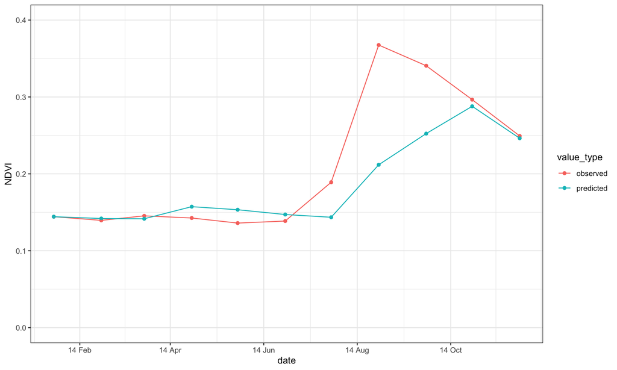

```r
ggplot(data = pred_ts2, aes(x = date, y = NDVI, color = value_type)) +
  geom_point() +
  geom_line() +
  scale_y_continuous(limits = c(0, 0.4)) +
  scale_x_date(breaks = "2 months",
               date_labels = "%y %b") +
  theme_bw()
```